# Analysis of TCGA lung adenocarcinoma cancer (LUAD) using ML approach

Estefania Mancini

May 2020

```r
library(ggplot2)
library(survival)
library(knitr)
library(kableExtra)
library(survminer)
library(ggfortify)
library(psichomics)
library(xtable)
library(corrplot)
library(caret)
library(e1071)
library(tree)
library(randomForest)
```

# 1 Introduction

The Cancer Genome Atlas (TCGA, https://www.cancer.gov/about-nci/organization/ccg/research/structural-genomics/tcga), molecularly characterized over 20,000 primary cancer and matched normal samples spanning 33 cancer types.

# 2 Data

- Raw data is available under folder <“data”>
- Serrano’s group shared with us the tables of the splicing events for LUNG cancer produced using (https://github.com/vastgroup/vast-tools). We extratcted PSI for NUMB EXON 9 (HsaEX0044216) as well as coversion tables for samples and clinical data (see <“../data/psi_lung_NA_NewN3.tab”/)
- Clinical data was obtained using psichomics (see https://www.bioconductor.org/packages/release/bioc/html/psichomics.html). See <../data/luad_clinical_psichomics.tab>.
- nrow=521 (samples)
- ncol=2591 (features)
- adin.disease_code=LUAD

```r
subset$newVar<-paste(subset$stage,
                     subset$gender, sep="_")

dfAg1<-data.frame(table(subset$newVar))
#Var1 viene del table
dfAg1<-cbind(dfAg1,
            data.frame(matrix(unlist(strsplit(as.character(dfAg1$Var1), "_")), ncol=2, byrow = T)))

colnames(dfAg1)[1]<-"comb"
colnames(dfAg1)[2]<-"NumOfSamples"
colnames(dfAg1)[3]<-"stage"
colnames(dfAg1)[4]<-"gender"

knitr::kable(dfAg1[,2:4], format="pandoc", align='cccc')
```

| NumOfSamples | stage | gender |
| --- | --- | --- |
| 5 | i | female |
| 83 | ia | female |
| 51 | ia | male |
| 75 | ib | female |
| 65 | ib | male |
| 1 | ii | female |
| 21 | iia | female |
| 29 | iia | male |
| 34 | iib | female |
| 39 | iib | male |
| 40 | iiia | female |
| 33 | iiia | male |
| 6 | iiib | female |
| 5 | iiib | male |
| 12 | iv | female |
| 14 | iv | male |
| 3 | NA | female |
| 5 | NA | male |

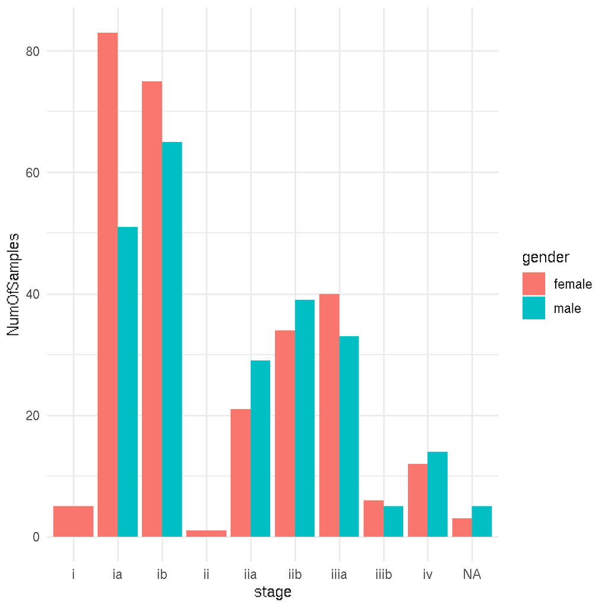

```r
ggplot(data=dfAg1, aes(x=stage, y=NumOfSamples, fill=gender)) +
  geom_bar(stat="identity",  position="dodge")+
  theme_minimal()
```

```r
subset$newVar2<-paste(subset$aggStage,
                      subset$gender,
                      sep="_")
dfAg2<-data.frame(table(subset$newVar2))
#Var1 viene del table
dfAg2<-cbind(dfAg2,
            data.frame(matrix(unlist(strsplit(as.character(dfAg2$Var1), "_")), ncol=2, byrow = T)))

colnames(dfAg2)[1]<-"comb"
colnames(dfAg2)[2]<-"NumOfSamples"
colnames(dfAg2)[3]<-"aggStage"
colnames(dfAg2)[4]<-"gender"

knitr::kable(dfAg2, format="pandoc", align='cccc')
```

| comb | NumOfSamples | aggStage | gender |
| --- | --- | --- | --- |
| early_female | 219 | early | female |
| early_male | 184 | early | male |
| late_female | 58 | late | female |
| late_male | 52 | late | male |
| NA_female | 3 | NA | female |
| NA_male | 5 | NA | male |

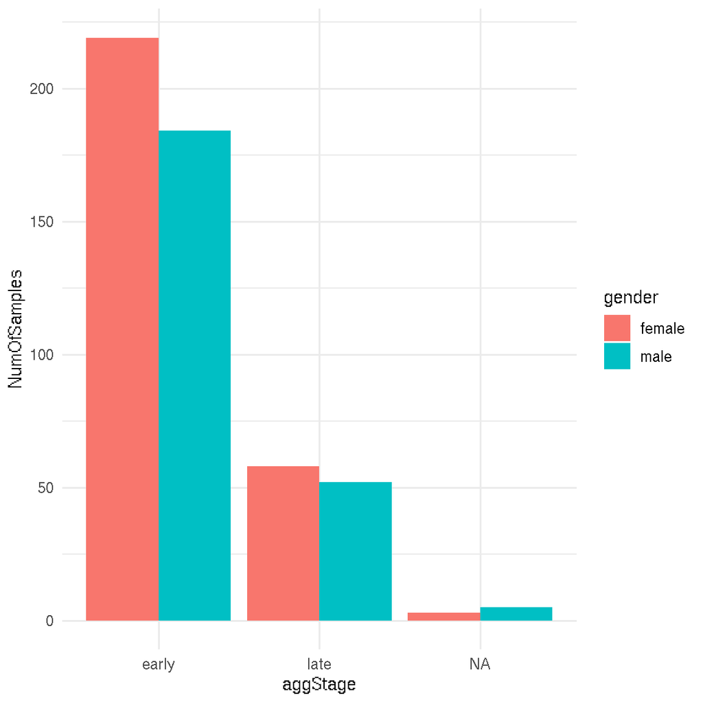

```r
ggplot(data=dfAg2, aes(x=aggStage, y=NumOfSamples, fill=gender)) +
  geom_bar(stat="identity",  position="dodge")+
  theme_minimal()
```

# 3 Descriptive

Here we analyze PSI distribution using several clinical variables in order to identify which variables could be useful for a ML approach

## 3.1 Statistical tests

We use:

- Wilcoxon test wilcox.test() Compare two groups (non-parametric)
- Kruskal-Wallis kruskal.test() Compare multiple groups (non-parametric)

See http://www.sthda.com/english/articles/24-ggpubr-publication-ready-plots/76-add-p-values-and-significance-levels-to-ggplots/

## 3.2 Analysis by type: normal or tumoral tissue (samples)

For the first analysis we compared the levels of NUMB exon 9 inclusion between healthy and tumoral tissue. In total 109 healthy samples (mean PSI 6.14) vs 495 tumoral samples (mean PSI 44.3) were compared using a Wilcoxon test.

This data suggests that lung tumors have a (significant) higher NUMB exon 9 PSI value than healthy tissue (p-value < 2.2e-16).

```r
normal<-dfPlots[dfPlots$type=="normal",]
print(paste("N normal:",dim(normal)[1]))
```

```
## [1] "N normal: 109"
```

```r
print(paste("Mean normal:",mean(normal$psi)))
```

```
## [1] "Mean normal: 6.14688073394495"
```

```r
tumor<-dfPlots[dfPlots$type=="tumor",]
print(paste("N tumoral:",dim(tumor) [1]))
```

```
## [1] "N tumoral: 495"
```

```r
print(paste("Mean tumoral:",mean(tumor$psi)))
```

```
## [1] "Mean tumoral: 44.2717575757576"
```

```r
wilcox.test(normal$psi, tumor$psi)
```

```
##
##  Wilcoxon rank sum test with continuity correction
##
## data:  normal$psi and tumor$psi
## W = 501.5, p-value < 2.2e-16
## alternative hypothesis: true location shift is not equal to 0
```

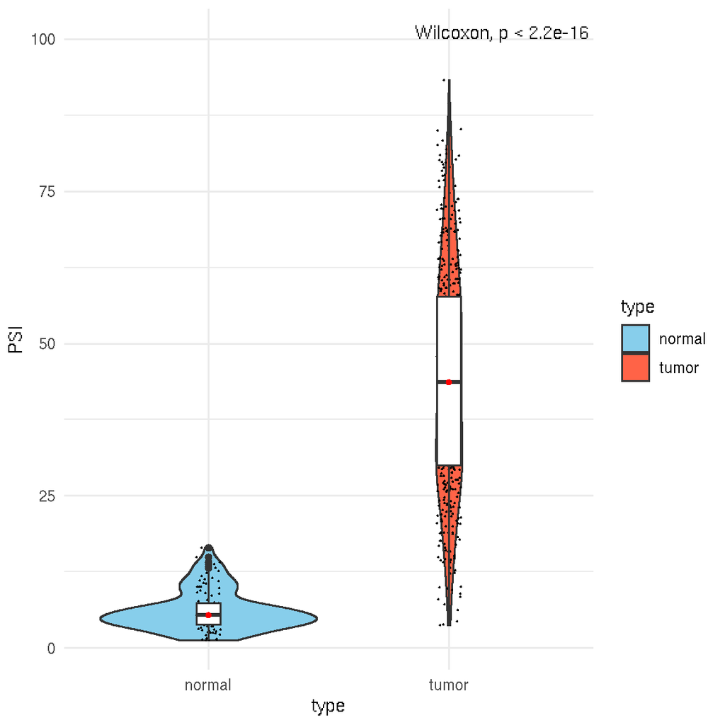

```r
numb_psi<-dfPlots[,1:2]
colnames(numb_psi) <- c("PSI","type")
ggplot(data= numb_psi, aes(x=type,y=PSI)) + geom_violin(aes(fill=type)) +
  scale_colour_manual(values = c("skyblue", "tomato")) +
  scale_fill_manual(values = c("skyblue", "tomato")) +
  theme(axis.text.x = element_text(angle = 90, hjust = 1))+
  geom_jitter(shape=16,
               position=position_jitter(0.05),
               size=.5,
               color=  "black")+
  geom_boxplot(width=0.1) +
  stat_summary(fun=median, geom="point", size=1, color="red")+   stat_compare_means(label.y = 100, label.x=2)+
  theme_minimal()
```

### 3.2.1 GTEX (caterina)

We also analyzed PSI value in healthy tissues, using The Genotype-Tissue Expression (GTEx) project data (https://www.gtexportal.org/home/)

- Vast-tool hg19,PSI range: 0-100
- median PSI values across lung samples = 3.52%
- mean PSI values across lung samples= 3.52%
- Range PSI values across lung samples= 20%

This data suggest PSI in healthy tissues is ~3.5 %

## 3.3 Analysis by stage

We analyzed PSI values according to their tumoral stage (provided in the clinical data) using a kruskal.test(). We didn’t find any significant differences between them according kruskal test (by stage pval 0.11 and by aaggStage pval = 0.8236)

```
##
##    i   ia   ib   ii  iia  iib iiia iiib   iv
##    5  127  138    1   47   67   68   11   25
```

```
##
##  Kruskal-Wallis rank sum test
##
## data:  psi by stage
## Kruskal-Wallis chi-squared = 12.959, df = 8, p-value = 0.1133
```

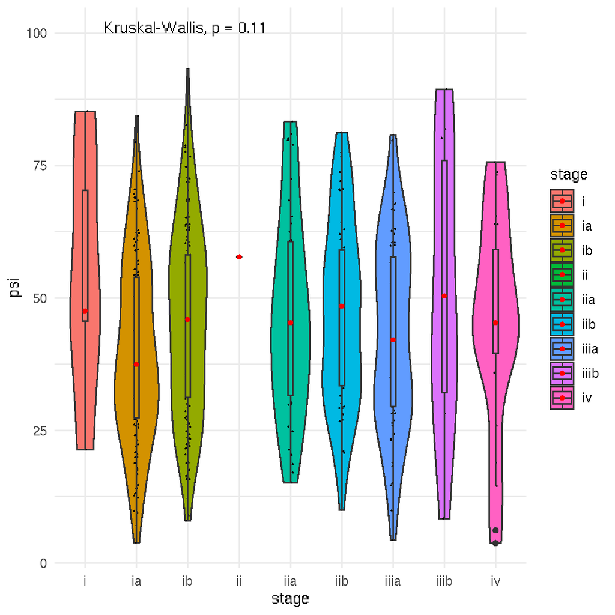

- (Now, re plot ordering by median, to improve visualization):

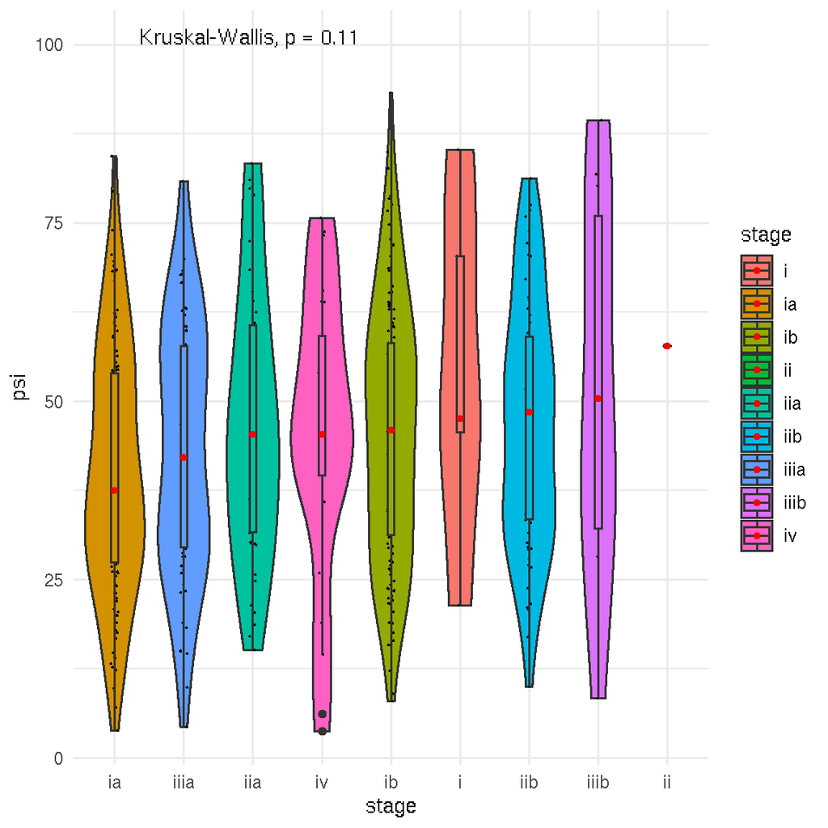

- **Results**: According Kruskal-Wallis ( p-value = 0.1133) there is no clear stage with (high) different psi.

## 3.4 Analysis by Aggregate stage

In order to have bigger groups, we aggregated the tumors in two main stages. Early (n=385, stage I to IIB) and Late (n=104, stage III and IV). We compared NUMB exon 9 PSI in these groups.

- **Results**: we didn’t find any significant differences between these 2 groups (Wilcoxon test pval 0.8236)

```
##
## early  late
##   385   104
```

```
##
##  Wilcoxon rank sum test with continuity correction
##
## data:  finalVNotNA$psi[finalVNotNA$aggStage == "early"] and finalVNotNA$psi[finalVNotNA$aggStage == "late"]
## W = 19734, p-value = 0.8236
## alternative hypothesis: true location shift is not equal to 0
```

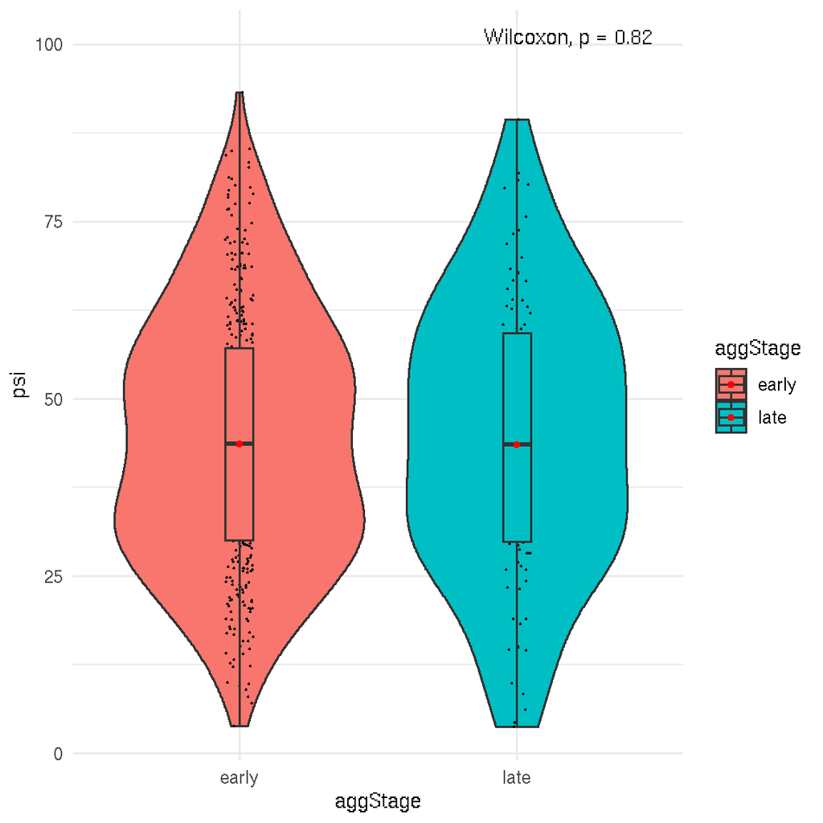

## 3.5 Analysis by gender

We compared NUMB exon 9 PSI in Male (n=224) vs Female (n=265) and also in Early and Late tumors.

- **Results** Male tumors usually have a higher PSI (Wilcoxon test, pvalue = 0.0036) and it seems the difference is more striking in the early stage tumors (Kruskal-Wallis test, p-value = 0.02076 )

```
##
## female   male
##    265    224
```

```
##
##  Wilcoxon rank sum test with continuity correction
##
## data:  finalVNotNA$psi[finalVNotNA$gender == "male"] and finalVNotNA$psi[finalVNotNA$gender == "female"]
## W = 34213, p-value = 0.0036
## alternative hypothesis: true location shift is not equal to 0
```

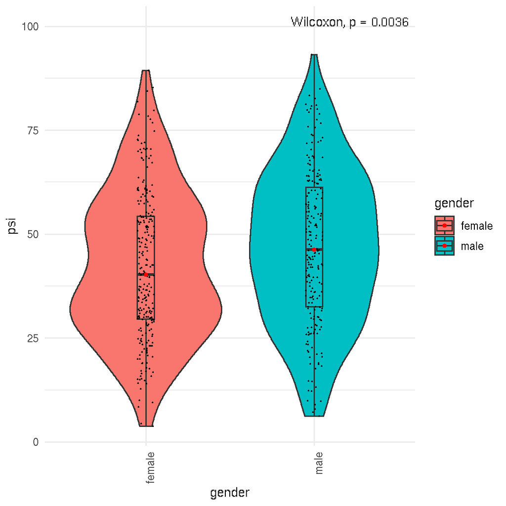

## 3.6 Analysis by gender and aggregate stage

- **Results**: both Wilcoxon and KW test are significant at early stage: male have higher PSI than female (pval=0.02)

```
## [1] "Early by gender:"
```

```
##
## female   male
##    210    175
```

```
## [1] "Late by gender:"
```

```
##
## female   male
##     55     49
```

```
## [1] "Kruskal-Wallis test:"
```

```
##
##  Kruskal-Wallis rank sum test
##
## data:  psi by gender
## Kruskal-Wallis chi-squared = 5.3465, df = 1, p-value = 0.02076
```

```
##
##  Kruskal-Wallis rank sum test
##
## data:  psi by gender
## Kruskal-Wallis chi-squared = 3.1837, df = 1, p-value = 0.07437
```

```
## [1] "Wilcoxon test:"
```

```
##
##  Wilcoxon rank sum test with continuity correction
##
## data:  early$psi[early$gender == "male"] and early$psi[early$gender == "female"]
## W = 20889, p-value = 0.02079
## alternative hypothesis: true location shift is not equal to 0
```

```
##
##  Wilcoxon rank sum test with continuity correction
##
## data:  late$psi[late$gender == "male"] and late$psi[late$gender == "female"]
## W = 1621.5, p-value = 0.0749
## alternative hypothesis: true location shift is not equal to 0
```

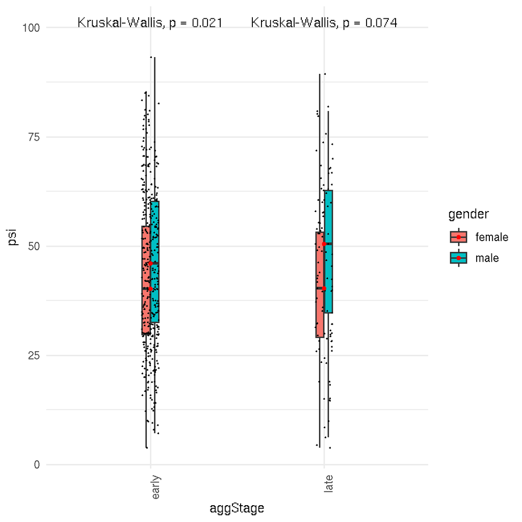

## 3.7 Correlation between NUMB exon 9 PSI and known LUAD driver mutations

Some of the most known cancer-related mutations are also clinically measured in the patients. We performed a correlation analysis to try to identify if there is any correlation between NUMB exon 9 inclusion levels and mutations in known genes.

- We found reported mutations in these genes:
  - KRAS, EGFR and ALK
- Mutations on these genes were not reported:
  - HER2, BRAF,DDR2,AKT,FGFR,NOTCH,TP53,CDH10,NFE2L2,KMT2C,CDKN2A,FAT1 and PI3KCA

### 3.7.1 *kras*

```
## [1] "KRAS mutation results:"
```

```
##
## g12a g12c g12d g12s g12v
##    4   12    1    1    2
```

```
## [1] "Number of YES sammples:20"
```

```r
print(table(finalV$kras_mutation_found))
```

```
##
##  no yes
## 474  21
```

```r
kruskal.test(finalV$psi ~ finalV$kras_mutation_found)
```

```
##
##  Kruskal-Wallis rank sum test
##
## data:  finalV$psi by finalV$kras_mutation_found
## Kruskal-Wallis chi-squared = 0.30373, df = 1, p-value = 0.5816
```

```r
wilcox.test(finalV$psi[finalV$kras_mutation_found =="yes"],
            finalV$psi[finalV$kras_mutation_found =="no"])
```

```
##
##  Wilcoxon rank sum test with continuity correction
##
## data:  finalV$psi[finalV$kras_mutation_found == "yes"] and finalV$psi[finalV$kras_mutation_found == "no"]
## W = 4623.5, p-value = 0.5821
## alternative hypothesis: true location shift is not equal to 0
```

```r
print(table(finalKras$kras_mutation_result))
```

```
##
## g12a g12c g12d g12s g12v
##    4   12    1    1    2
```

```r
kruskal.test(finalKras$psi ~ finalKras$kras_mutation_result)
```

```
##
##  Kruskal-Wallis rank sum test
##
## data:  finalKras$psi by finalKras$kras_mutation_result
## Kruskal-Wallis chi-squared = 3.3452, df = 4, p-value = 0.5018
```

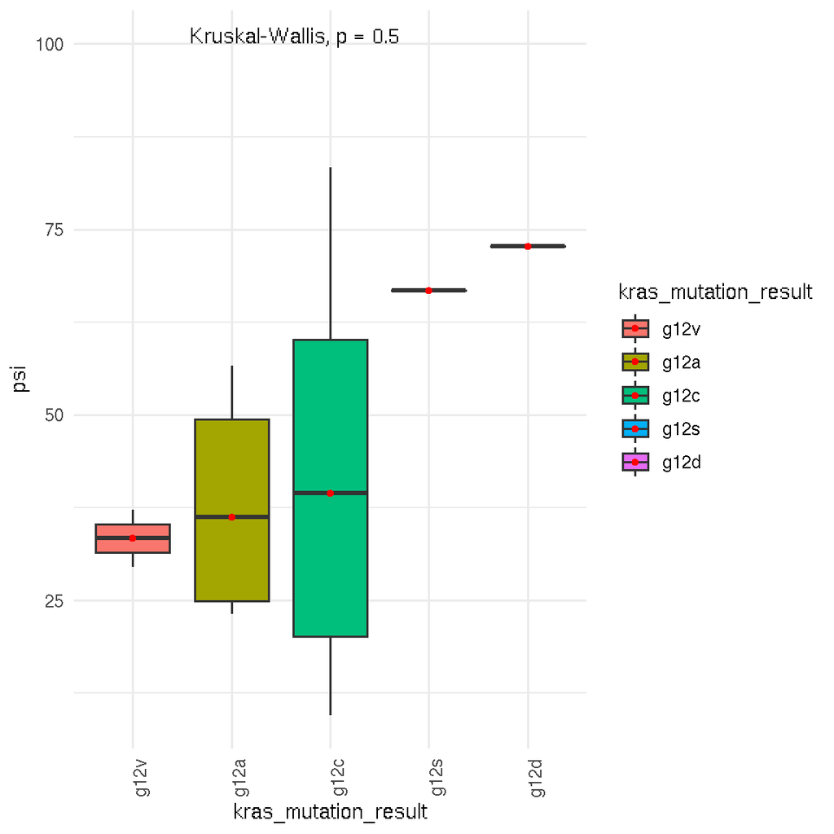

```r
finalKras$kras_mutation_result = with(finalKras, reorder(kras_mutation_result, psi, median))
ggplot(finalKras, aes(x=kras_mutation_result, y=psi,
                        fill=kras_mutation_result))+
    geom_boxplot()   +
    #geom_jitter(shape=16,                position=position_jitter(0.05), size=.5,  color=  "black")+
    stat_summary(fun=median, geom="point", size=1, color="red")+     stat_compare_means(label.y = 100, label.x=2)+
    theme_minimal()+
    theme(axis.text.x = element_text(angle = 90, hjust = 1))
```

- (3, yes by gender) Mutation results by gender (already ordered, i think is not needed)

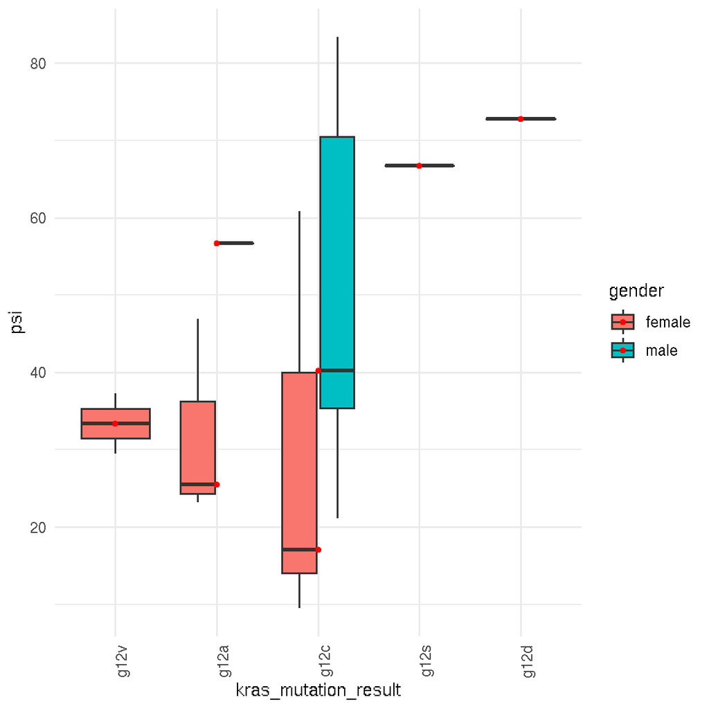

```r
  ggplot(finalKras, aes(x=kras_mutation_result, y=psi,
                        fill=gender))+
    geom_boxplot()   +
    #geom_jitter(shape=16,                position=position_jitter(0.05), size=.5,  color=  "black")+
    stat_summary(fun=median, geom="point", size=1, color="red")+            stat_compare_means(label.y = 100, label.x=2)+
    theme_minimal()+
    theme(axis.text.x = element_text(angle = 90, hjust = 1))
```

- (4, g12c) We repeated only for g12c (N=12), it seems has a difference by gender, but it is not statistically significant (p-value = 0.149)

```r
g12c<-finalKras[finalKras$kras_mutation_result=="g12c",]
print(table(g12c$kras_mutation_result))
```

```
##
## g12v g12a g12c g12s g12d
##    0    0   12    0    0
```

```r
wilcox.test(g12c$psi[g12c$gender =="male"],
            g12c$psi[g12c$gender =="female"])
```

```
##
##  Wilcoxon rank sum exact test
##
## data:  g12c$psi[g12c$gender == "male"] and g12c$psi[g12c$gender == "female"]
## W = 27, p-value = 0.149
## alternative hypothesis: true location shift is not equal to 0
```

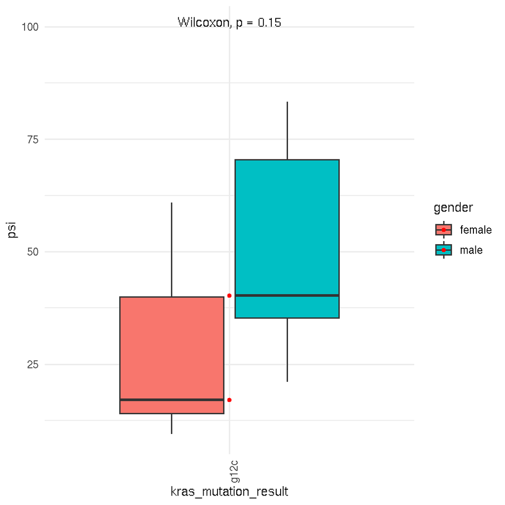

```r
ggplot(g12c, aes(x=kras_mutation_result, y=psi,
                        fill=gender))+
    geom_boxplot()   +
   #geom_jitter(shape=16,                position=position_jitter(0.05), size=.5,  color=  "black")+
    stat_summary(fun=median, geom="point", size=1, color="red")+    stat_compare_means(label.y = 100, label.x=2)+
    theme_minimal()+
    theme(axis.text.x = element_text(angle = 90, hjust = 1))
```

- 5. Mutation result by aggregate stage: Con este N tan pequeño, no veo que tenga sentido este analisis

```r
print(table(finalKras$aggStage))
```

```
##
## early  late
##    16     4
```

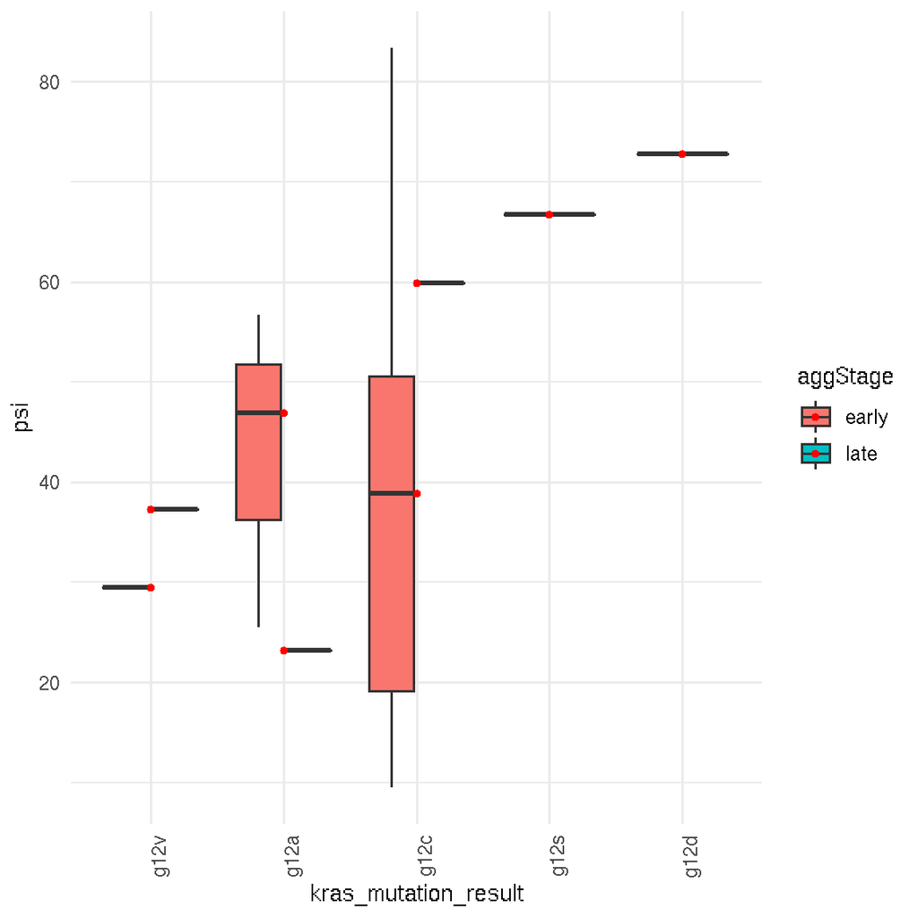

```r
ggplot(finalKras, aes(x=kras_mutation_result,
                      y=psi,
                      fill=aggStage))+
    geom_boxplot()   +
    #geom_jitter(shape=16,                position=position_jitter(0.05), size=.5,  color=  "black")+
    stat_summary(fun=median, geom="point", size=1, color="red")+    stat_compare_means(label.y = 100, label.x=2)+
    theme_minimal()+
    theme(axis.text.x = element_text(angle = 90, hjust = 1))
```

### 3.7.2 *egfr*

- Samples with mutation analysis performed:
  - YES: 76,
  - NO: 419 (NAs were replaced by “NO”)
- (1 yes vs no) There is not statistically significant differences between these 2 groups (p-value = 0.6). *Note that in 76 cases with mutation found (YES), 53 have not a definition/type and 9 are “other”*

```
##
##  no yes
## 419  76
```

```
##
##  Kruskal-Wallis rank sum test
##
## data:  finalV$psi by finalV$egfr_mutation_performed
## Kruskal-Wallis chi-squared = 0.25076, df = 1, p-value = 0.6165
```

```
##
## exon 19 deletion            l858r            l861q               ns
##                9                3                1               53
##            other            t790m
##                9                1
```

```
##
##  Kruskal-Wallis rank sum test
##
## data:  finalVE$psi by finalVE$egfr_mutation_result
## Kruskal-Wallis chi-squared = 3.8362, df = 5, p-value = 0.5732
```

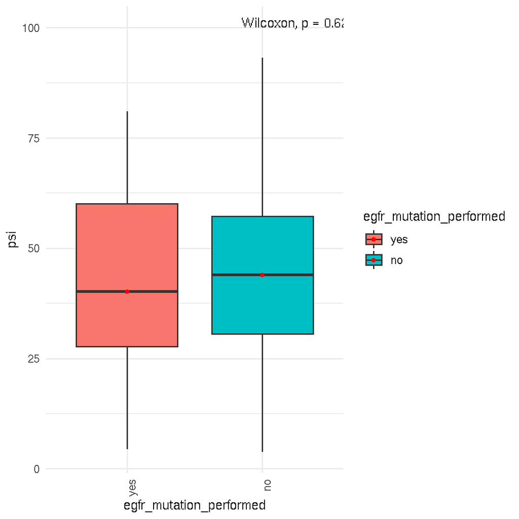

```r
ggplot(finalV, aes(x=egfr_mutation_performed, y=psi, fill=egfr_mutation_performed))+
    geom_boxplot()   +
    #geom_jitter(shape=16,                position=position_jitter(0.05), size=.5,  color=  "black")+
    stat_summary(fun=median, geom="point", size=1, color="red")+     stat_compare_means(label.y = 100, label.x=2)+
    theme_minimal()+
    theme(axis.text.x = element_text(angle = 90, hjust = 1))
```

- (2, only yes) Mutation results (reorder by median PSI):

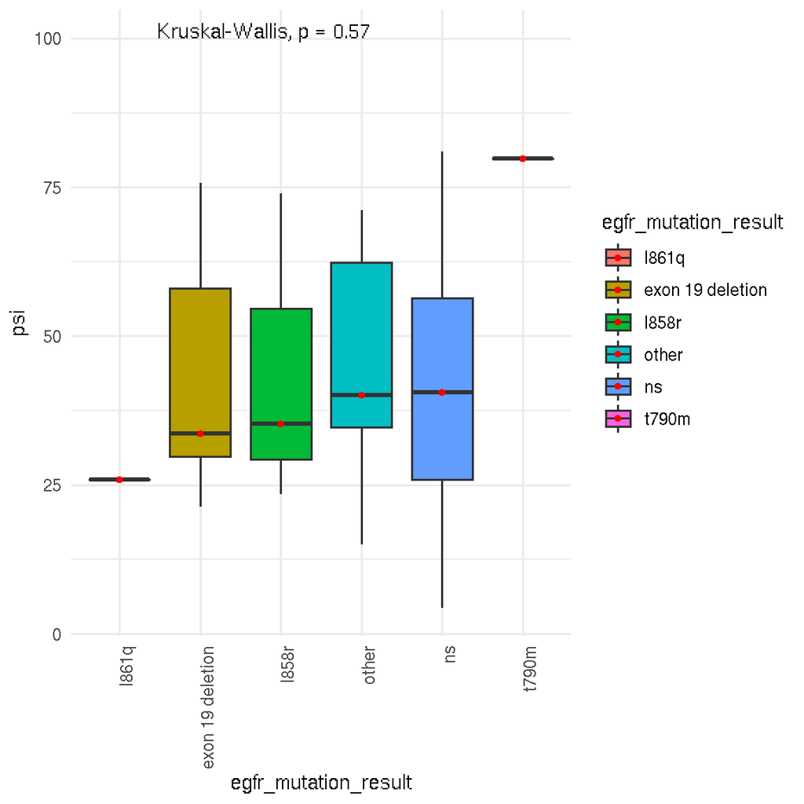

```r
finalVE$egfr_mutation_result = with(finalVE, reorder(egfr_mutation_result, psi, median))

ggplot(finalVE, aes(x=egfr_mutation_result, y=psi, fill=egfr_mutation_result))+
    geom_boxplot()   +
    #geom_jitter(shape=16,                position=position_jitter(0.05), size=.5,  color=  "black")+
    stat_summary(fun=median, geom="point", size=1, color="red")+    stat_compare_means(label.y = 100, label.x=2)+
    theme_minimal()+
    theme(axis.text.x = element_text(angle = 90, hjust = 1))
```

- 3. Mutation results by gender (should be reordered by median)

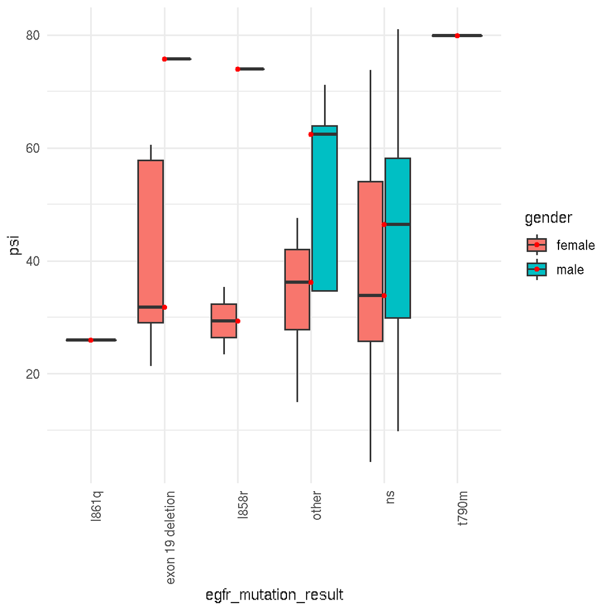

```r
  ggplot(finalVE, aes(x=egfr_mutation_result, y=psi, fill=gender))+
    geom_boxplot()   +
    #geom_jitter(shape=16,                position=position_jitter(0.05), size=.5,  color=  "black")+
    stat_summary(fun=median, geom="point", size=1, color="red")+    #stat_compare_means(label.y = 100, label.x=2)+
    theme_minimal()+
    theme(axis.text.x = element_text(angle = 90, hjust = 1))
```

- 4. Mutation results by aggStage (should be reorder)

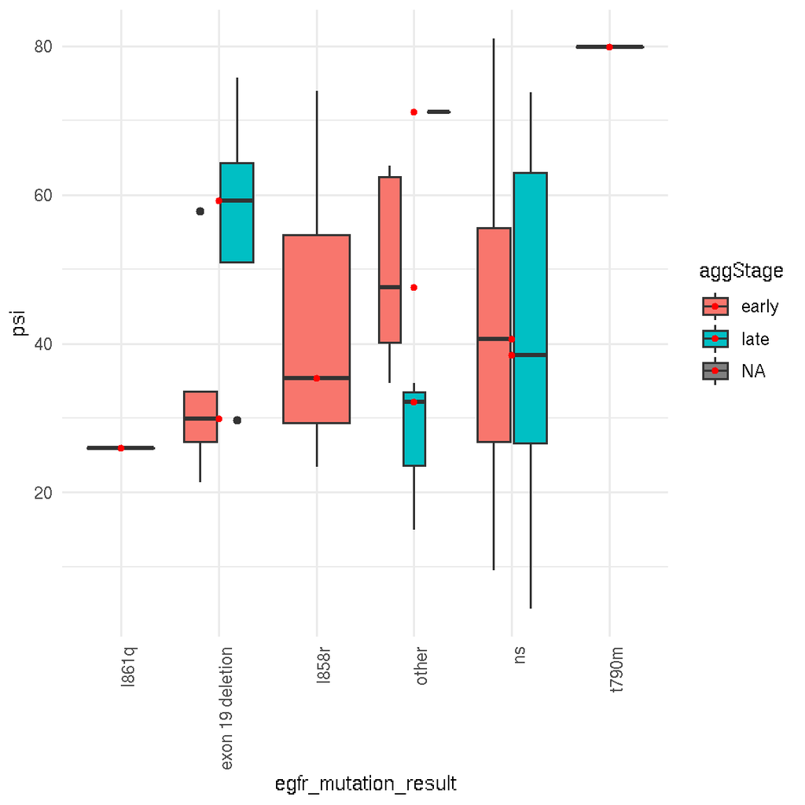

```r
  ggplot(finalVE, aes(x=egfr_mutation_result, y=psi, fill=aggStage))+
    geom_boxplot()   +
    #geom_jitter(shape=16,                position=position_jitter(0.05), size=.5,  color=  "black")+
    stat_summary(fun=median, geom="point", size=1, color="red")+    stat_compare_means(label.y = 100, label.x=2)+
    theme_minimal()+
    theme(axis.text.x = element_text(angle = 90, hjust = 1))
```

### 3.7.3 *alk*

```r
print("Before cleaning")
```

```
## [1] "Before cleaning"
```

```r
table(finalV$eml4_alk_translocation_performed)
```

```
##
##  no yes
## 205  33
```

```r
finalV$eml4_alk_translocation_performed[is.na(finalV$eml4_alk_translocation_performed)]<-"no"
finalV$eml4_alk_translocation_method[is.na(finalV$eml4_alk_translocation_method)]<-"no"

print("After cleaning")
```

```
## [1] "After cleaning"
```

```r
print("Performed")
```

```
## [1] "Performed"
```

```r
table(finalV$eml4_alk_translocation_performed)
```

```
##
##  no yes
## 462  33
```

```r
print("Method")
```

```
## [1] "Method"
```

```r
table(finalV$eml4_alk_translocation_method)
```

```
##
##   fish    ihc     no rt-pcr
##     19      3    470      3
```

```r
alkYes<-finalV[finalV$eml4_alk_translocation_performed=="yes",]
alkYes<-alkYes[!is.na(alkYes$eml4_alk_translocation_performed),]

print("Dim alkyes")
```

```
## [1] "Dim alkyes"
```

```r
dim(alkYes)
```

```
## [1] 33 37
```

```r
print("Performed")
```

```
## [1] "Performed"
```

```r
table(alkYes$eml4_alk_translocation_performed)
```

```
##
## yes
##  33
```

```r
print("Method")
```

```
## [1] "Method"
```

```r
table(alkYes$dimeml4_alk_translocation_method)
```

```
## < table of extent 0 >
```

```r
alkYes<-alkYes[!is.na(alkYes$eml4_alk_translocation_method),]

print("Dim alkyes")
```

```
## [1] "Dim alkyes"
```

```r
dim(alkYes)
```

```
## [1] 33 37
```

```r
print("Performed")
```

```
## [1] "Performed"
```

```r
table(alkYes$eml4_alk_translocation_performed)
```

```
##
## yes
##  33
```

```r
print("Method")
```

```
## [1] "Method"
```

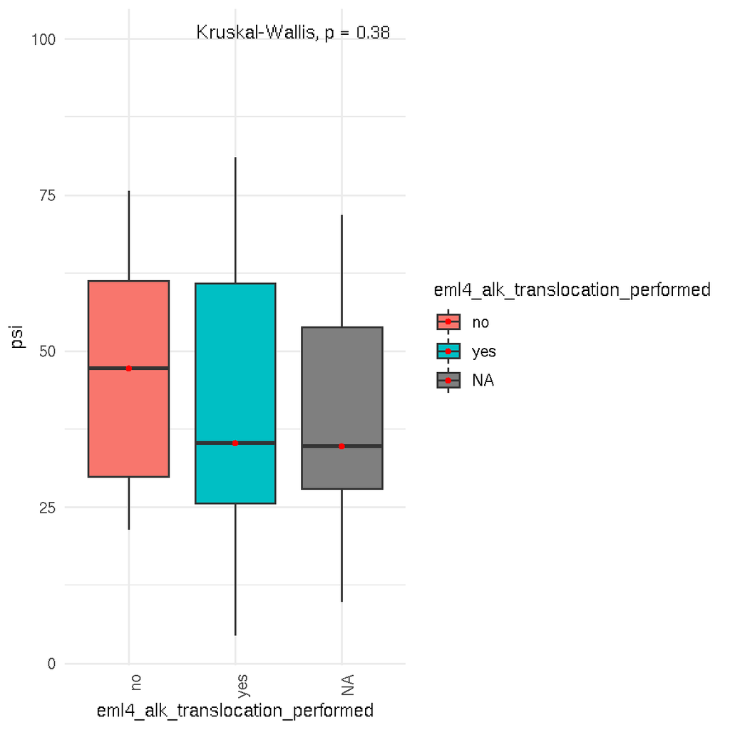

```r
 ggplot(finalVE,
         aes(x=eml4_alk_translocation_performed,
             y=psi,
             fill=eml4_alk_translocation_performed))+
    geom_boxplot()   +
#geom_jitter(shape=16,                position=position_jitter(0.05), size=.5,  color=  "black")+
stat_summary(fun=median, geom="point", size=1, color="red")+    stat_compare_means(label.y = 100, label.x=2)+
    theme_minimal()+
    theme(axis.text.x = element_text(angle = 90, hjust = 1))
```

- (2, yes) Plots deberia estar ordenado, sacar NA de resultado ?

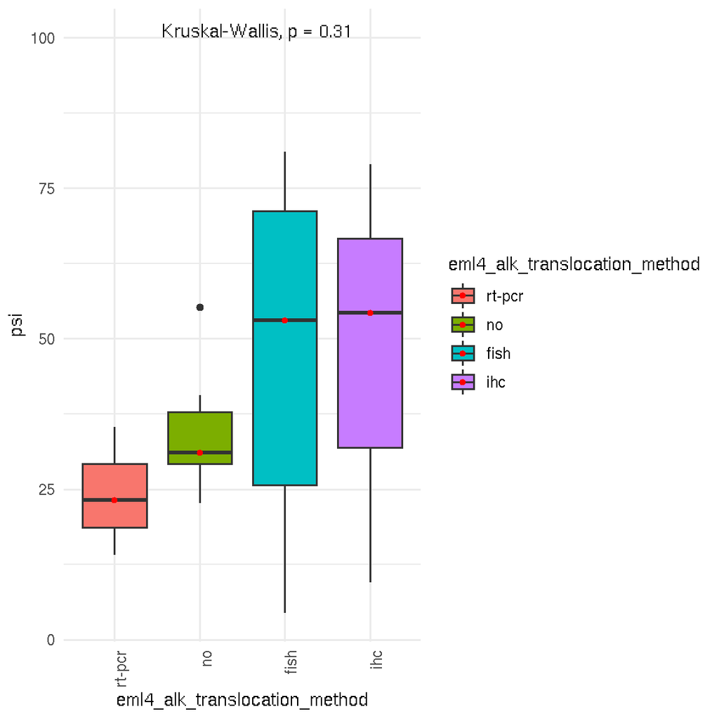

```r
alkYes$eml4_alk_translocation_method = with(alkYes, reorder(eml4_alk_translocation_method, psi, median))
ggplot(alkYes, aes(x=eml4_alk_translocation_method, y=psi, fill=eml4_alk_translocation_method))+
    geom_boxplot()   +
  #geom_jitter(shape=16,                position=position_jitter(0.05), size=.5,  color=  "black")+
    stat_summary(fun=median, geom="point", size=1, color="red")+            stat_compare_means(label.y = 100, label.x=2)+
    theme_minimal()+
    theme(axis.text.x = element_text(angle = 90, hjust = 1))
```

## 3.8 Treatment Success

We also explored the PSI in different groups according their treatment success:

### 3.8.1 (1) Follow up: follow up treatment success

- Variable name: follow_ups.follow_up.followup_treatment_success
- **Results**: We didnt find differences (pval clean data 0.29)

```r
finalV$follow_ups.follow_up.followup_treatment_success<-
  as.character(finalV$follow_ups.follow_up.followup_treatment_success)

finalV$follow_ups.follow_up.followup_treatment_success[is.na(finalV$follow_ups.follow_up.followup_treatment_success)]<-"unknown"


print(
  table(finalV$follow_ups.follow_up.followup_treatment_success))
```

```
##
## complete remission/response  partial remission/response
##                         194                           9
##         progressive disease              stable disease
##                          92                          31
##                     unknown
##                         169
```

```r
##########################################################
#remuevo los unknown
clean<-finalV[finalV$follow_ups.follow_up.followup_treatment_success!="unknown",]
#remuevo los partial remission response
clean<-clean[clean$follow_ups.follow_up.followup_treatment_success!="partial remission/response",]
dim(clean)#234
```

```
## [1] 317  37
```

```r
table(clean$follow_ups.follow_up.followup_treatment_success)
```

```
##
## complete remission/response         progressive disease
##                         194                          92
##              stable disease
##                          31
```

```r
clean$follow_ups.follow_up.followup_treatment_success<-
  factor(clean$follow_ups.follow_up.followup_treatment_success,
         c("complete remission/response",
           "stable disease","progressive disease"))
###########################################################
```

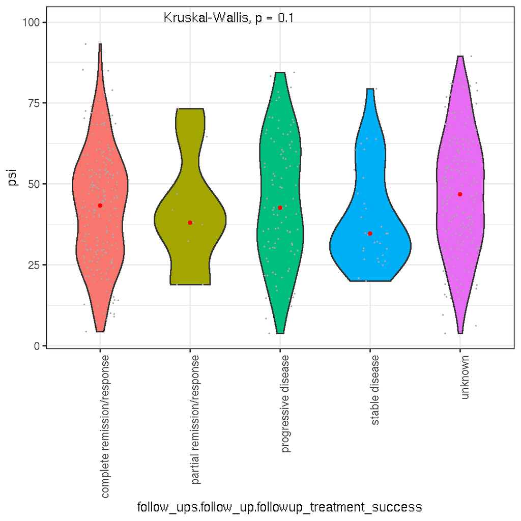

```r
ggplot(finalV,
       aes(x=follow_ups.follow_up.followup_treatment_success,
           y=psi,
           fill=follow_ups.follow_up.followup_treatment_success))+
  geom_violin()   +
  theme_bw()+
  geom_jitter(shape=16,
              position=position_jitter(0.2),
              size=.5, color="darkgrey")     +
  stat_summary(fun=median, geom="point", size=1, color="red")  +
  stat_compare_means(label.y = 100, label.x=2)+
  theme(legend.position="none") +
  theme(axis.text.x = element_text(angle = 90, hjust = 1))
```

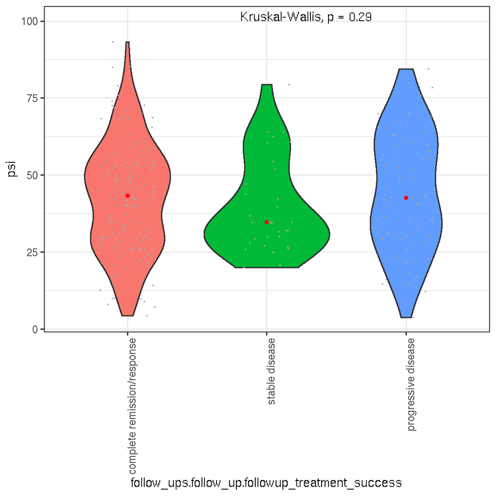

```r
ggplot(clean,
       aes(x=follow_ups.follow_up.followup_treatment_success,
           y=psi,
           fill=follow_ups.follow_up.followup_treatment_success))+
  geom_violin()   +
  theme_bw()+
  geom_jitter(shape=16,
              position=position_jitter(0.2),
              size=.5, color="darkgrey")     +
  stat_summary(fun=median, geom="point", size=1, color="red")  +
  stat_compare_means(label.y = 100, label.x=2)+
  theme(legend.position="none") +
  theme(axis.text.x = element_text(angle = 90, hjust = 1))
```

- (1b) Repito reorder by median PSI:

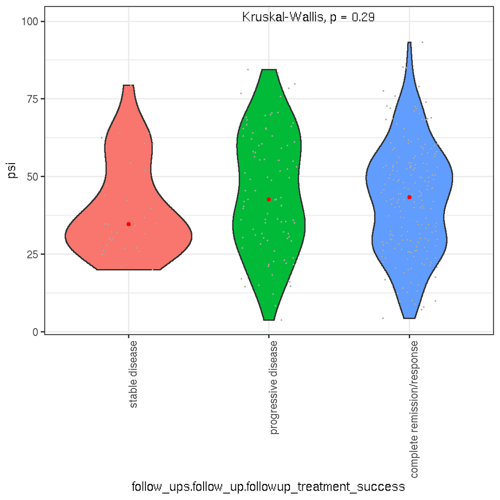

```r
clean$follow_ups.follow_up.followup_treatment_success = with(clean, reorder(follow_ups.follow_up.followup_treatment_success, psi, median))

ggplot(clean,
       aes(x=follow_ups.follow_up.followup_treatment_success,
           y=psi,
           fill=follow_ups.follow_up.followup_treatment_success))+
  geom_violin()   +
  theme_bw()+
  geom_jitter(shape=16,
              position=position_jitter(0.2),
              size=.5, color="darkgrey")     +
  stat_summary(fun=median, geom="point", size=1, color="red")  +
  stat_compare_means(label.y = 100, label.x=2)+
  theme(legend.position="none") +
  theme(axis.text.x = element_text(angle = 90, hjust = 1))
```

### 3.8.2 (2) follow_ups.follow_up.primary_therapy_outcome_success :

- Variable: follow_ups.follow_up.primary_therapy_outcome_success
- **Results**: not significant difference according KW test

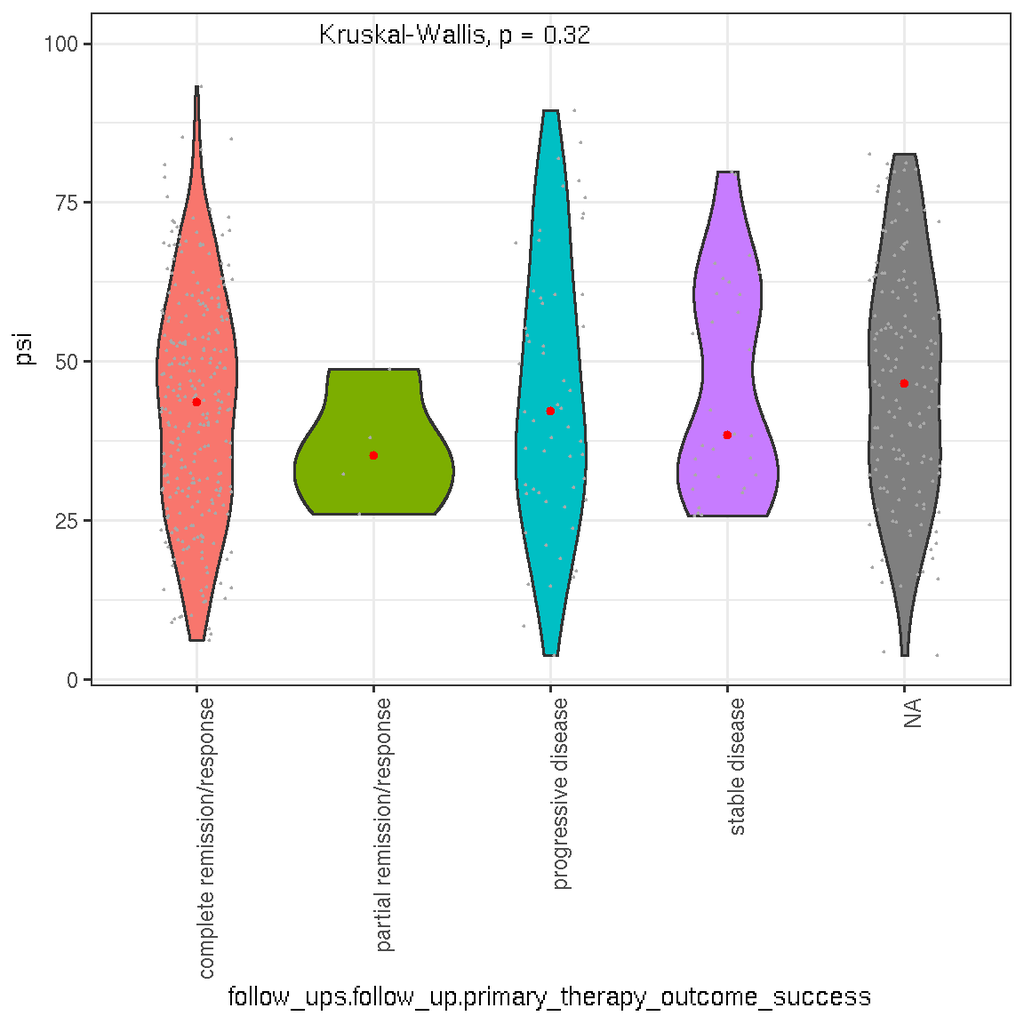

```r
ggplot(finalV,
       aes(x=follow_ups.follow_up.primary_therapy_outcome_success,
           y=psi,
           fill=follow_ups.follow_up.primary_therapy_outcome_success))+
  geom_violin()   +
  theme_bw()+
  geom_jitter(shape=16,
              position=position_jitter(0.2),
              size=.5, color="darkgrey")     +
  stat_summary(fun=median, geom="point", size=1, color="red")  +
  stat_compare_means(label.y = 100, label.x=2)+
  theme(legend.position="none") +
  theme(axis.text.x = element_text(angle = 90, hjust = 1))
```

```r
table(clean$follow_ups.follow_up.primary_therapy_outcome_success)
```

```
##
## complete remission/response  partial remission/response
##                         225                           2
##         progressive disease              stable disease
##                          44                          24
```

```r
#remuevo los unknown
clean<-finalV[!is.na(finalV$follow_ups.follow_up.primary_therapy_outcome_success),]
clean<-clean[clean$follow_ups.follow_up.primary_therapy_outcome_success!="partial remission/response",]
dim(clean)#234
```

```
## [1] 351  37
```

```r
table(clean$follow_ups.follow_up.primary_therapy_outcome_success)
```

```
##
## complete remission/response         progressive disease
##                         265                          56
##              stable disease
##                          30
```

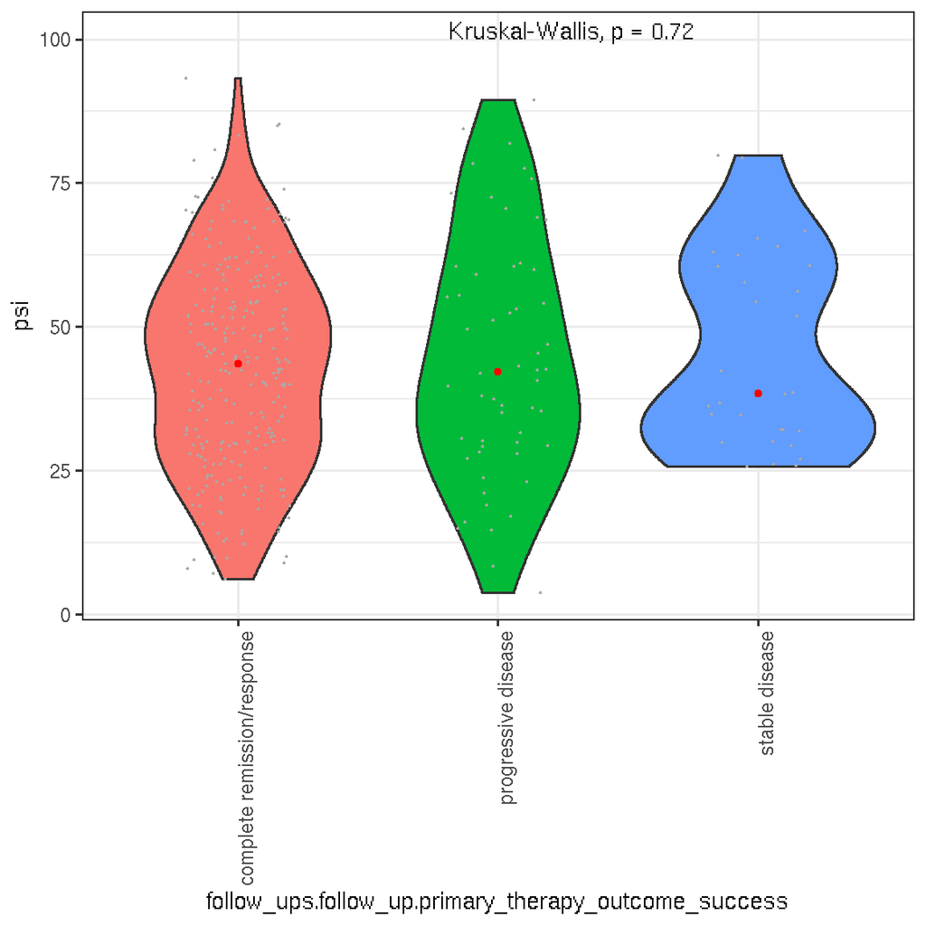

```r
ggplot(clean,
       aes(x=follow_ups.follow_up.primary_therapy_outcome_success,
           y=psi,
           fill=follow_ups.follow_up.primary_therapy_outcome_success))+
  geom_violin()   +
  theme_bw()+
  geom_jitter(shape=16,
              position=position_jitter(0.2),
              size=.5, color="darkgrey")     +
  stat_summary(fun=median, geom="point", size=1, color="red")  +
  stat_compare_means(label.y = 100, label.x=2)+
  theme(legend.position="none") +
  theme(axis.text.x = element_text(angle = 90, hjust = 1))
```

- (2b) Repito clean and reorder:
  - **Results**: not differences between groups

```r
clean$follow_ups.follow_up.primary_therapy_outcome_success = with(clean, reorder(follow_ups.follow_up.primary_therapy_outcome_success, psi, median))
table(clean$follow_ups.follow_up.primary_therapy_outcome_success)
```

```
##
##              stable disease         progressive disease
##                          30                          56
## complete remission/response
##                         265
```

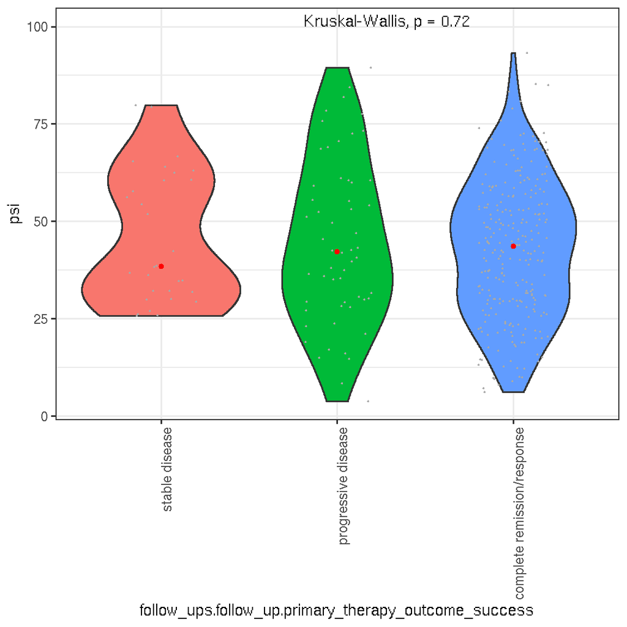

```r
ggplot(clean,
       aes(x=follow_ups.follow_up.primary_therapy_outcome_success,
           y=psi,
           fill=follow_ups.follow_up.primary_therapy_outcome_success))+
  geom_violin()   +
  theme_bw()+
  geom_jitter(shape=16,
              position=position_jitter(0.2),
              size=.5, color="darkgrey")     +
  stat_summary(fun=median, geom="point", size=1, color="red")  +
  stat_compare_means(label.y = 100, label.x=2)+
  theme(legend.position="none") +
  theme(axis.text.x = element_text(angle = 90, hjust = 1))
```

### 3.8.3 Primary therapy outcome success

- variable: primary_therapy_outcome_success
- **Results**: It seems that PSI values correlates (pval 0.04) with the progression of the disease, following this order
- complete remission/response
- stable disease
- progressive disease

```r
finalV$primary_therapy_outcome_success<-as.character(finalV$primary_therapy_outcome_success)

finalV$primary_therapy_outcome_success[is.na(finalV$primary_therapy_outcome_success)]<-"unknown"
table(finalV$primary_therapy_outcome_success)
```

```
##
## complete remission/response  partial remission/response
##                         126                           2
##         progressive disease              stable disease
##                           7                          12
##                     unknown
##                         348
```

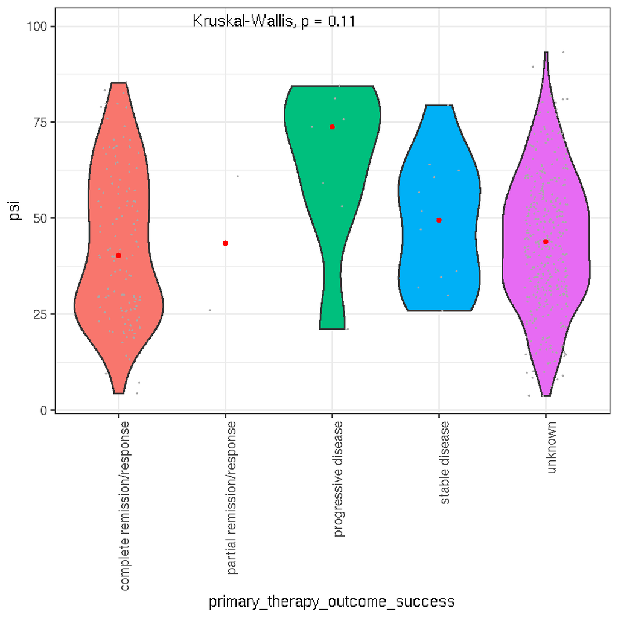

```r
ggplot(finalV,
       aes(x=primary_therapy_outcome_success,
           y=psi,
           fill=primary_therapy_outcome_success))+
  geom_violin()   +
  theme_bw()  +
  geom_jitter(shape=16,
              position=position_jitter(0.2),
              size=.5, color="darkgrey")     +
  stat_summary(fun=median, geom="point", size=1, color="red")  +
  stat_compare_means(label.y = 100, label.x=2)+
  theme(legend.position="none") +
  theme(axis.text.x = element_text(angle = 90, hjust = 1))
```

```r
finalV$primary_therapy_outcome_success<-as.character(finalV$primary_therapy_outcome_success)

finalV$primary_therapy_outcome_success[is.na(finalV$primary_therapy_outcome_success)]<-"unknown"
table(finalV$primary_therapy_outcome_success)
```

```
##
## complete remission/response  partial remission/response
##                         126                           2
##         progressive disease              stable disease
##                           7                          12
##                     unknown
##                         348
```

```r
clean<-finalV[finalV$primary_therapy_outcome_success!="unknown",]
clean<-clean[clean$primary_therapy_outcome_success!="partial remission/response",]
clean<-clean[!is.na(clean$primary_therapy_outcome_success),]
table(clean$primary_therapy_outcome_success)
```

```
##
## complete remission/response         progressive disease
##                         126                           7
##              stable disease
##                          12
```

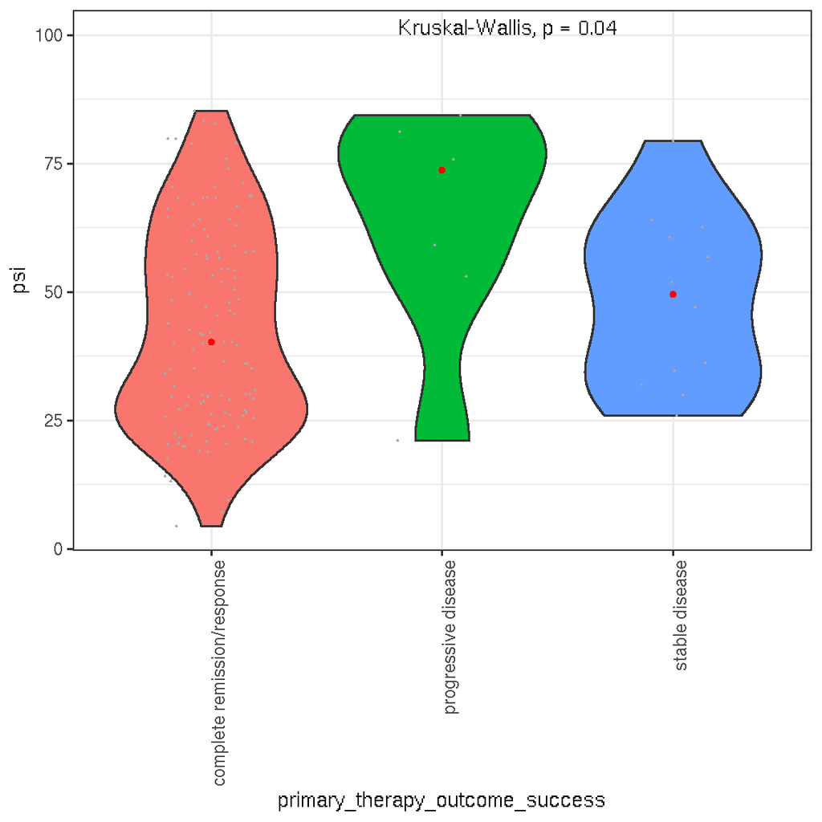

```r
ggplot(clean,
       aes(x=primary_therapy_outcome_success,
           y=psi,
           fill=primary_therapy_outcome_success))+
  geom_violin()   +
  theme_bw()  +
  geom_jitter(shape=16,
              position=position_jitter(0.2),
              size=.5, color="darkgrey")     +
  stat_summary(fun=median, geom="point", size=1, color="red")  +
  stat_compare_means(label.y = 100, label.x=2)+
  theme(legend.position="none") +
  theme(axis.text.x = element_text(angle = 90, hjust = 1))
```

- (3b) repito order

```r
table(clean$primary_therapy_outcome_success)
```

```
##
## complete remission/response         progressive disease
##                         126                           7
##              stable disease
##                          12
```

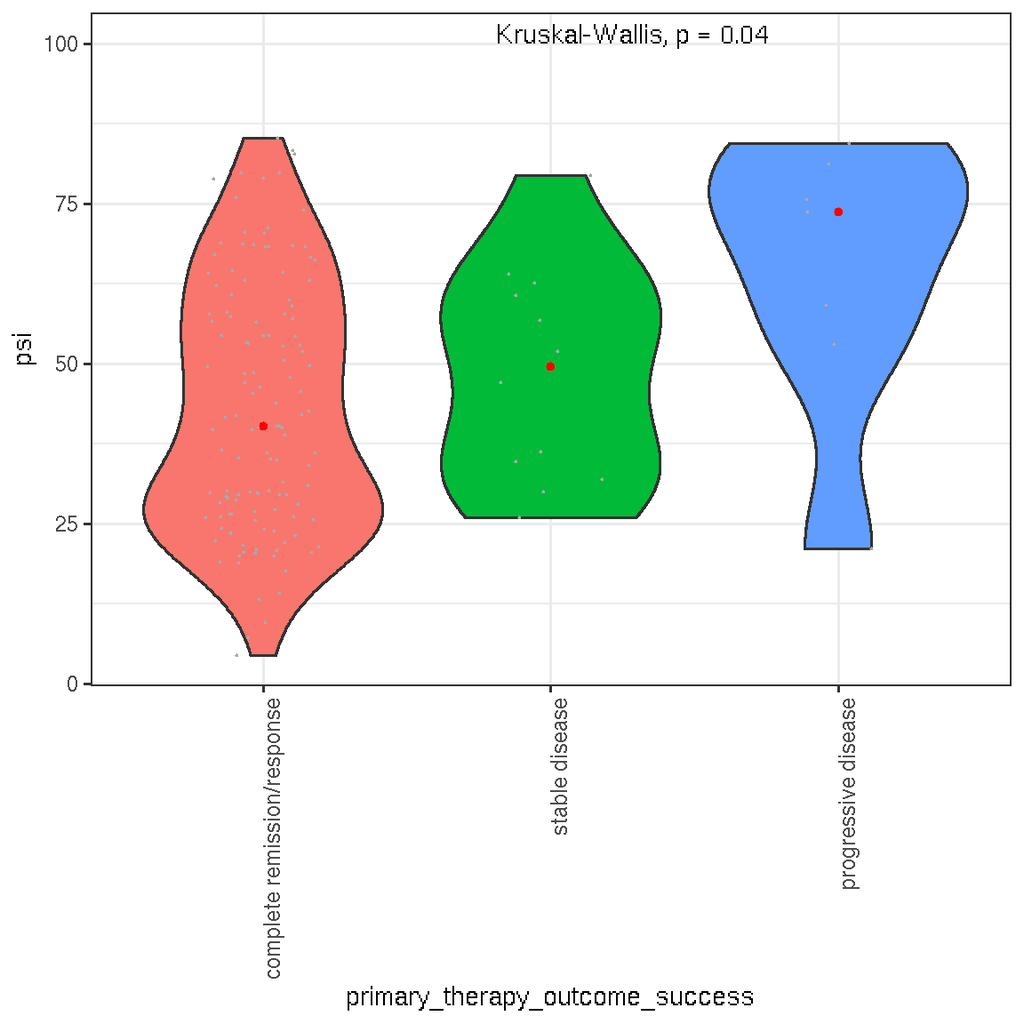

```r
clean$primary_therapy_outcome_success = with(clean, reorder(primary_therapy_outcome_success, psi, median))

ggplot(clean,
       aes(x=primary_therapy_outcome_success,
           y=psi,
           fill=primary_therapy_outcome_success))+
  geom_violin()   +
  theme_bw()  +
  geom_jitter(shape=16,
              position=position_jitter(0.2),
              size=.5, color="darkgrey")     +
  stat_summary(fun=median, geom="point", size=1, color="red")  +
  stat_compare_means(label.y = 100, label.x=2)+
  theme(legend.position="none") +
  theme(axis.text.x = element_text(angle = 90, hjust = 1))
```

## 3.9 Neoplasm cancer status

We wanted to check if there were any difference according tumor types. There is not significant difference (WT, pval 0.96)

```r
finalV$person_neoplasm_cancer_status<-as.character(finalV$person_neoplasm_cancer_status)
finalV$person_neoplasm_cancer_status[is.na(finalV$person_neoplasm_cancer_status)]<-"unknown"
print("Before cleaning")
```

```
## [1] "Before cleaning"
```

```r
table(finalV$person_neoplasm_cancer_status)
```

```
##
## tumor free    unknown with tumor
##        297         92        106
```

```r
#remvove unknown
finalVNotUnknown<-finalV[finalV$person_neoplasm_cancer_status!="unknown",]
finalVNotUnknown<-finalVNotUnknown[!is.na(finalV$person_neoplasm_cancer_status),]
finalVNotUnknown<-finalVNotUnknown[finalVNotUnknown$person_neoplasm_cancer_status!="NA",]
print("After cleaning")
```

```
## [1] "After cleaning"
```

```r
table(finalVNotUnknown$person_neoplasm_cancer_status)
```

```
##
## tumor free with tumor
##        297        106
```

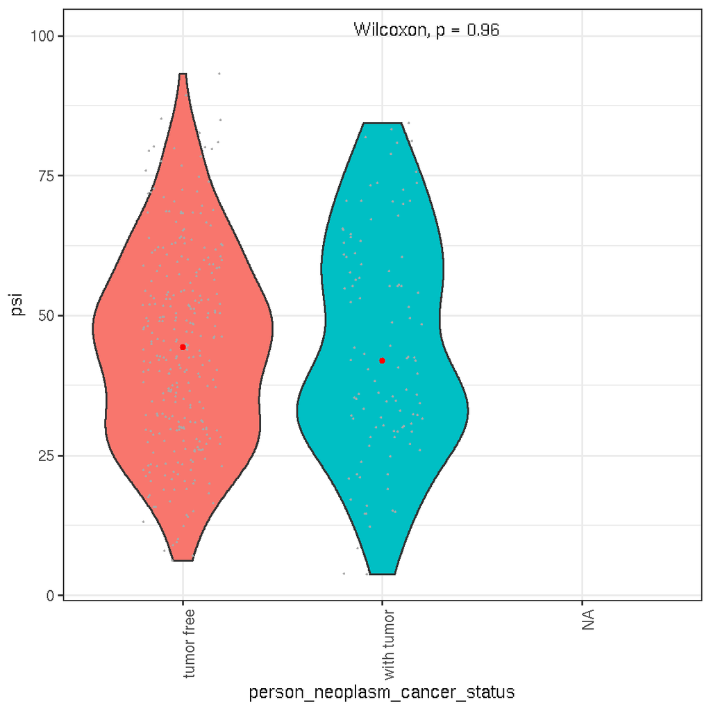

```r
ggplot(finalVNotUnknown,
       aes(x=person_neoplasm_cancer_status,
           y=psi,
           fill=person_neoplasm_cancer_status ))+
  geom_violin()   +
  theme_bw()+
  geom_jitter(shape=16,
              position=position_jitter(0.2),
              size=.5, color="darkgrey")     +
  stat_summary(fun=median, geom="point", size=1, color="red")  +
  stat_compare_means(label.y = 100, label.x=2)+
  theme(legend.position="none") +
  theme(axis.text.x = element_text(angle = 90, hjust = 1))
```

## 3.10 Sample types

We didnt find significance differences in PSI according sample type (pval 0.91)

```r
finalV$samples.sample.2.sample_type<-as.character(finalV$samples.sample.2.sample_type)
finalV$samples.sample.2.sample_type[is.na(finalV$samples.sample.2.sample_type)]<-"unknown"
table(finalV$samples.sample.2.sample_type)
```

```
##
## blood derived normal         ffpe scrolls        primary tumor
##                  391                    2                   11
##      recurrent tumor  solid tissue normal
##                    2                   89
```

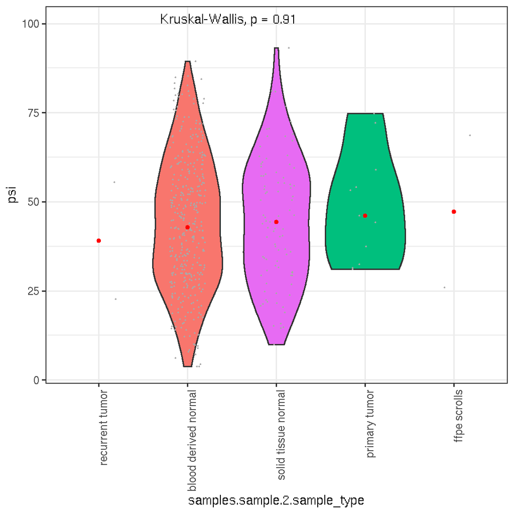

```r
#order:
finalV$samples.sample.2.sample_type = with(finalV, reorder(samples.sample.2.sample_type, psi, median))

ggplot(finalV,
       aes(x=samples.sample.2.sample_type, y=psi, fill=samples.sample.2.sample_type))+
  geom_violin()   +
  theme_bw()+
  geom_jitter(shape=16,
              position=position_jitter(0.2),
              size=.5, color="darkgrey")     +
  stat_summary(fun=median, geom="point", size=1, color="red")  +
  stat_compare_means(label.y = 100, label.x=2)+
  theme(legend.position="none") +
  theme(axis.text.x = element_text(angle = 90, hjust = 1))
```

## 3.11 Smokers

Explore if there is any relationship between PSI and Smoke. There are 337 patients which reported: “number pack years smoked”

```r
smoking<-finalV[!is.na(finalV$number_pack_years_smoked),]
dim(smoking)
```

```
## [1] 337  37
```

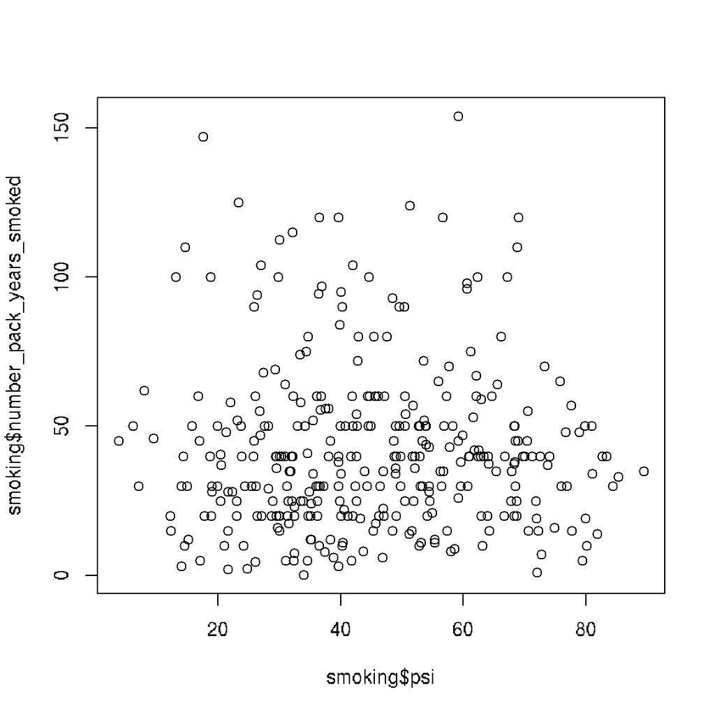

```r
plot(smoking$psi, smoking$number_pack_years_smoked)
```

```r
cor(smoking$psi, smoking$number_pack_years_smoked)
```

```
## [1] -0.003979449
```

```r
lm(smoking$psi ~ smoking$number_pack_years_smoked)
```

```
##
## Call:
## lm(formula = smoking$psi ~ smoking$number_pack_years_smoked)
##
## Coefficients:
##                      (Intercept)  smoking$number_pack_years_smoked
##                        44.971649                         -0.002645
```

### 3.11.1 Age:

```r
#cor(finalV$psi, finalV$age_at_initial_pathologic_diagnosis)
lm(finalV$psi ~ finalV$age_at_initial_pathologic_diagnosis)
```

```
##
## Call:
## lm(formula = finalV$psi ~ finalV$age_at_initial_pathologic_diagnosis)
##
## Coefficients:
##                                (Intercept)
##                                   50.40029
## finalV$age_at_initial_pathologic_diagnosis
##                                   -0.09155
```

```r
#colnames(finalV)
```

## 3.12 Our variables more interesting are:

- outcome (predictor): 0 (dead) or 1 (alive)
  - Variables: gender, age (age_at_initial_pathologic_diagnosis), stage, aggStage, PSI, smoker (number pack years smoked),
- Discarded:
  - mutations
  - treatment succes

```r
MLdf<- data.frame(
    finalV$vital_status, #esta es la variable respuesta
    finalV$gender,
    finalV$psi,
    finalV$age_at_initial_pathologic_diagnosis,
    finalV$number_pack_years_smoked,
    finalV$aggStage)
head(MLdf)
```

```
##   finalV.vital_status finalV.gender finalV.psi
## 1               alive          male       7.95
## 2               alive          male      35.10
## 3                dead          male      71.86
## 4                dead        female      48.07
## 5               alive        female      55.89
## 6               alive          male      60.57
##   finalV.age_at_initial_pathologic_diagnosis finalV.number_pack_years_smoked
## 1                                         68                              62
## 2                                         66                              20
## 3                                         76                              19
## 4                                         57                              NA
## 5                                         74                              65
## 6                                         62                              98
##   finalV.aggStage
## 1           early
## 2            late
## 3            late
## 4            late
## 5           early
## 6           early
```

```r
colnames(MLdf)<-gsub("finalV.", "", colnames(MLdf))
MLdf$vital_status[MLdf$vital_status=="dead"]<-0
MLdf$vital_status[MLdf$vital_status=="alive"]<-1
#apply(MLdf, 2, summary)
#removemos NAS y vemos cuantas rows quedan sin NAs:
#solo dejemos los numericos, sin NA:
clean<-MLdf[,c("vital_status",
               "psi",
              "age_at_initial_pathologic_diagnosis",
              "number_pack_years_smoked")]
#head(clean)
notNAs<-clean[rowSums(is.na(clean))==0,]
notNAs$age_at_initial_pathologic_diagnosis<- as.numeric(notNAs$age_at_initial_pathologic_diagnosis)
notNAs$number_pack_years_smoked<- as.numeric(notNAs$number_pack_years_smoked)
dim(notNAs)
```

```
## [1] 325   4
```

```r
head(notNAs)
```

```
##   vital_status   psi age_at_initial_pathologic_diagnosis
## 1            1  7.95                                  68
## 2            1 35.10                                  66
## 3            0 71.86                                  76
## 5            1 55.89                                  74
## 6            1 60.57                                  62
## 7            0 67.71                                  69
##   number_pack_years_smoked
## 1                       62
## 2                       20
## 3                       19
## 5                       65
## 6                       98
## 7                       25
```

```r
colnames(notNAs)
```

```
## [1] "vital_status"                        "psi"
## [3] "age_at_initial_pathologic_diagnosis" "number_pack_years_smoked"
```

```r
apply(notNAs[,-1],2, summary)
```

```
##              psi age_at_initial_pathologic_diagnosis number_pack_years_smoked
## Min.     3.83000                            33.00000                  0.15000
## 1st Qu. 31.07000                            59.00000                 22.50000
## Median  42.70000                            66.00000                 40.00000
## Mean    44.84803                            65.08308                 42.39215
## 3rd Qu. 58.51000                            72.00000                 52.00000
## Max.    89.39000                            88.00000                154.00000
```

```r
apply(notNAs[,-1],2, class)
```

```
##                                 psi age_at_initial_pathologic_diagnosis
##                           "numeric"                           "numeric"
##            number_pack_years_smoked
##                           "numeric"
```

```r
apply(notNAs[,-1],2, mean)
```

```
##                                 psi age_at_initial_pathologic_diagnosis
##                            44.84803                            65.08308
##            number_pack_years_smoked
##                            42.39215
```

# 4 Prepare dsets:

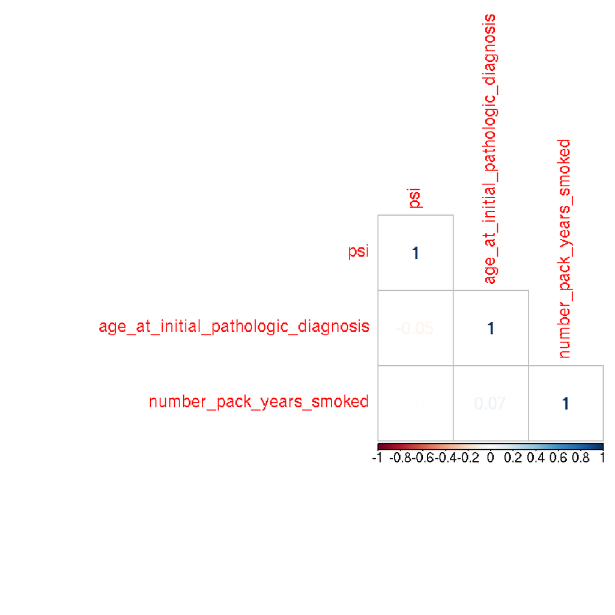

```r
corrplot(cor(notNAs[, -1]), type = "lower", method = "number")
```

```r
# Preparing the DataSet
set.seed(123)
n <- nrow(notNAs)
train <- sample(n, trunc(0.70*n))
training <- notNAs[train, ]
dim(training)
```

```
## [1] 227   4
```

```r
testing <- notNAs[-train, ]
dim(testing)
```

```
## [1] 98  4
```

```r
#glm_fm1 <-glm(vital_status ~., data = pima_training, family = binomial)
```